# Practical Machine Learning

# Introduction

Using devices such as Jawbone Up, Nike FuelBand, and Fitbit it is now possible to collect a large amount of data about personal activity relatively inexpensively. These type of devices are part of the quantified self movement - a group of enthusiasts who take measurements about themselves regularly to improve their health, to find patterns in their behavior, or because they are tech geeks. One thing that people regularly do is quantify how much of a particular activity they do, but they rarely quantify how well they do it. In this project, your goal will be to use data from accelerometers on the belt, forearm, arm, and dumbell of 6 participants. They were asked to perform barbell lifts correctly and incorrectly in 5 different ways.

The goal of your project is to predict the manner in which they did the exercise. This is the “classe” variable in the training set.I need to create a report describing how I built my model, how I used cross validation, what I think the expected out of sample error is, and why I made the choices you did. I will also use your prediction model to predict 20 different test cases.

# Analysis

## Approach

I am going to take following approach: 1. Load the data and understanding basic charateristics of data 2.I will use cross validation to build a model. 70% of training data will be used for subtraining data and 30% of training data will be used for subtesting data 3. I will understand the relationshp among variables and use Principal component Analysis to reduce the number of variables 4. I will use both decision tree and random forest models. 5. I will use both the models to find accuracy of both models on the subtesting dataset and then choose the best model 6. Finally I will apply the best model on the actual test data set

## Loading the data

I will load the data and packages, which I am going to use. I will also set the seed so that it can be reproducible

```r
library(caret)
library(randomForest)
```

```r
library(rpart)
library(rpart.plot)
set.seed(1234)
#Read the csv file and convert all #Div/0 to NA
training_set <- read.csv("pml-training.csv",na.strings=c("NA","#DIV/0!", ""))
testing_set <- read.csv("pml-testing.csv",na.strings=c("NA","#DIV/0!", ""))
head(training_set)
```

```
##   X user_name raw_timestamp_part_1 raw_timestamp_part_2   cvtd_timestamp
## 1 1  carlitos           1323084231               788290 05/12/2011 11:23
## 2 2  carlitos           1323084231               808298 05/12/2011 11:23
## 3 3  carlitos           1323084231               820366 05/12/2011 11:23
## 4 4  carlitos           1323084232               120339 05/12/2011 11:23
## 5 5  carlitos           1323084232               196328 05/12/2011 11:23
## 6 6  carlitos           1323084232               304277 05/12/2011 11:23
##   new_window num_window roll_belt pitch_belt yaw_belt total_accel_belt
## 1         no         11      1.41       8.07    -94.4                3
## 2         no         11      1.41       8.07    -94.4                3
## 3         no         11      1.42       8.07    -94.4                3
## 4         no         12      1.48       8.05    -94.4                3
## 5         no         12      1.48       8.07    -94.4                3
## 6         no         12      1.45       8.06    -94.4                3
##   kurtosis_roll_belt kurtosis_picth_belt kurtosis_yaw_belt
```

[output cut: 265 more lines]

```r
str(training_set)
```

```
## 'data.frame':    19622 obs. of  160 variables:
##  $ X                       : int  1 2 3 4 5 6 7 8 9 10 ...
##  $ user_name               : Factor w/ 6 levels "adelmo","carlitos",..: 2 2 2 2 2 2 2 2 2 2 ...
##  $ raw_timestamp_part_1    : int  1323084231 1323084231 1323084231 1323084232 1323084232 1323084232 1323084232 1323084232 1323084232 1323084232 ...
##  $ raw_timestamp_part_2    : int  788290 808298 820366 120339 196328 304277 368296 440390 484323 484434 ...
##  $ cvtd_timestamp          : Factor w/ 20 levels "02/12/2011 13:32",..: 9 9 9 9 9 9 9 9 9 9 ...
##  $ new_window              : Factor w/ 2 levels "no","yes": 1 1 1 1 1 1 1 1 1 1 ...
##  $ num_window              : int  11 11 11 12 12 12 12 12 12 12 ...
##  $ roll_belt               : num  1.41 1.41 1.42 1.48 1.48 1.45 1.42 1.42 1.43 1.45 ...
##  $ pitch_belt              : num  8.07 8.07 8.07 8.05 8.07 8.06 8.09 8.13 8.16 8.17 ...
##  $ yaw_belt                : num  -94.4 -94.4 -94.4 -94.4 -94.4 -94.4 -94.4 -94.4 -94.4 -94.4 ...
##  $ total_accel_belt        : int  3 3 3 3 3 3 3 3 3 3 ...
##  $ kurtosis_roll_belt      : num  NA NA NA NA NA NA NA NA NA NA ...
##  $ kurtosis_picth_belt     : num  NA NA NA NA NA NA NA NA NA NA ...
##  $ kurtosis_yaw_belt       : logi  NA NA NA NA NA NA ...
```

[output cut: 86 more lines]

## Cleaning of data

As we can see that there are a lot of variables for which all the values are “NA”" , so we need to nremove those variables from our dataset.

```r
training_set<-training_set[,colSums(is.na(training_set)) == 0]
testing_set<-testing_set[,colSums(is.na(testing_set)) == 0]
str(training_set)
```

```
## 'data.frame':    19622 obs. of  60 variables:
##  $ X                   : int  1 2 3 4 5 6 7 8 9 10 ...
##  $ user_name           : Factor w/ 6 levels "adelmo","carlitos",..: 2 2 2 2 2 2 2 2 2 2 ...
##  $ raw_timestamp_part_1: int  1323084231 1323084231 1323084231 1323084232 1323084232 1323084232 1323084232 1323084232 1323084232 1323084232 ...
##  $ raw_timestamp_part_2: int  788290 808298 820366 120339 196328 304277 368296 440390 484323 484434 ...
##  $ cvtd_timestamp      : Factor w/ 20 levels "02/12/2011 13:32",..: 9 9 9 9 9 9 9 9 9 9 ...
##  $ new_window          : Factor w/ 2 levels "no","yes": 1 1 1 1 1 1 1 1 1 1 ...
##  $ num_window          : int  11 11 11 12 12 12 12 12 12 12 ...
##  $ roll_belt           : num  1.41 1.41 1.42 1.48 1.48 1.45 1.42 1.42 1.43 1.45 ...
##  $ pitch_belt          : num  8.07 8.07 8.07 8.05 8.07 8.06 8.09 8.13 8.16 8.17 ...
##  $ yaw_belt            : num  -94.4 -94.4 -94.4 -94.4 -94.4 -94.4 -94.4 -94.4 -94.4 -94.4 ...
##  $ total_accel_belt    : int  3 3 3 3 3 3 3 3 3 3 ...
##  $ gyros_belt_x        : num  0 0.02 0 0.02 0.02 0.02 0.02 0.02 0.02 0.03 ...
##  $ gyros_belt_y        : num  0 0 0 0 0.02 0 0 0 0 0 ...
##  $ gyros_belt_z        : num  -0.02 -0.02 -0.02 -0.03 -0.02 -0.02 -0.02 -0.02 -0.02 0 ...
```

[output cut: 46 more lines]

Now we can see that the total number of variables necessary for us reduces from 160 to 60. We need to remove the variables X,user_name, raw_timestamp_part_1, raw_timestamp_part_,2 cvtd_timestamp, new_window, and num_window as they can’t be used for prediction

```r
remove <- grep("name|timestamp|window|X", colnames(training_set), value=F)
training_set <- training_set[,-remove]
testing_set <- testing_set[,-remove]
dim(training_set)
```

```
## [1] 19622    53
```

```r
dim(testing_set)
```

```
## [1] 20 53
```

## Crossvalidation

Now, we need to partition the training set into subtraining (70%) and subtesting(30%) data. This is to perform crossvalidation

```r
partition_data <- createDataPartition(y=training_set$classe, p=0.7, list=FALSE)
sub_training <- training_set[partition_data, ]
sub_testing <- training_set[-partition_data, ]
dim(sub_training)
```

```
## [1] 13737    53
```

```r
dim(sub_testing)
```

```
## [1] 5885   53
```

We can see that subtraining set has 13737 observations with 53 variables and subtesting set has 5885 observations with variables

## Bar Plot

As we know that the variable classe has 5 levels: A, B,C,D,E , let’s take a look at the frequency of each levels in subtraining data set

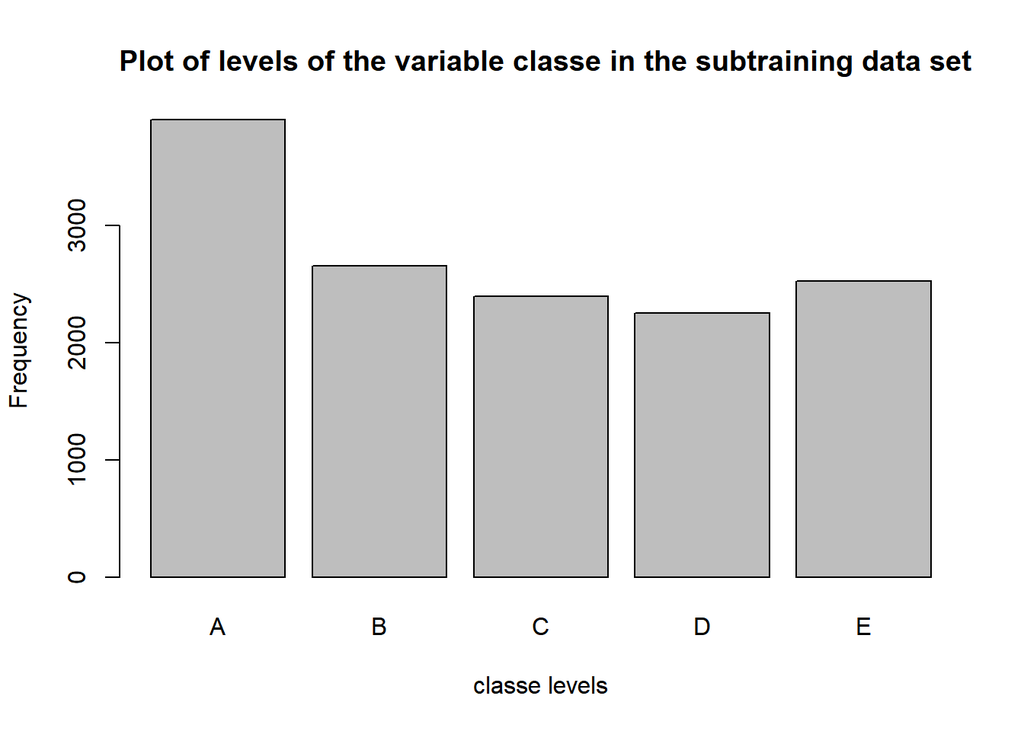

```r
plot(sub_training$classe, col="grey", main=" Plot of levels of the variable classe in the subtraining data set", xlab="classe levels", ylab="Frequency")
```

So, we can clearly see that A has highest observations while D has lowest observations.

## Prediction with Decison Tree

Lets’s first use decision tree model to model our data

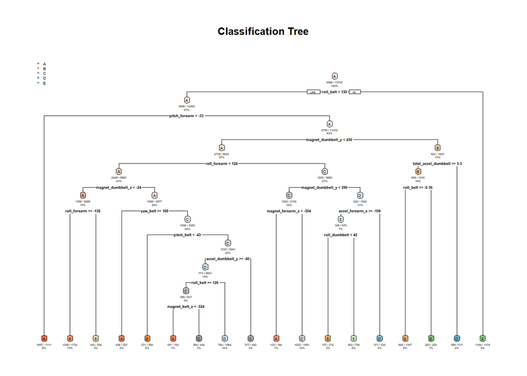

```r
model1 <- rpart(classe ~ ., data=sub_training, method="class")

prediction1 <- predict(model1, sub_testing, type = "class")

# Plot the Decision Tree
rpart.plot(model1, main="Classification Tree", extra=102, under=TRUE, faclen=0)
```

Let’s have a look at confusion matrix

```r
confusionMatrix(prediction1, sub_testing$classe)
```

```
## Confusion Matrix and Statistics
##
##           Reference
## Prediction    A    B    C    D    E
##          A 1364  169   24   48   16
##          B   60  581   46   79   74
##          C   52  137  765  129  145
##          D  183  194  125  650  159
##          E   15   58   66   58  688
##
## Overall Statistics
##
##                Accuracy : 0.6879
##                  95% CI : (0.6758, 0.6997)
##     No Information Rate : 0.2845
##     P-Value [Acc > NIR] : < 2.2e-16
##
##                   Kappa : 0.6066
##  Mcnemar's Test P-Value : < 2.2e-16
##
## Statistics by Class:
##
##                      Class: A Class: B Class: C Class: D Class: E
## Sensitivity            0.8148  0.51010   0.7456   0.6743   0.6359
## Specificity            0.9390  0.94543   0.9047   0.8657   0.9590
## Pos Pred Value         0.8415  0.69167   0.6230   0.4958   0.7774
## Neg Pred Value         0.9273  0.88940   0.9440   0.9314   0.9212
## Prevalence             0.2845  0.19354   0.1743   0.1638   0.1839
## Detection Rate         0.2318  0.09873   0.1300   0.1105   0.1169
## Detection Prevalence   0.2754  0.14274   0.2087   0.2228   0.1504
## Balanced Accuracy      0.8769  0.72776   0.8252   0.7700   0.7974
```

## PCA

As we can see that number of variables are still over 50, let’s use PCA to reduce some variables

```r
preProc <- preProcess(sub_training[, 1:52], method="pca",thresh=.95)
trainPC <- predict(preProc,sub_training[,1:52])
```

## Prediction with Random Forest

Let’s use Random Forest model

```r
modFitRF <- randomForest(sub_training$classe ~ .,   data=trainPC)
print(modFitRF)
```

```
##
## Call:
##  randomForest(formula = sub_training$classe ~ ., data = trainPC)
##                Type of random forest: classification
##                      Number of trees: 500
## No. of variables tried at each split: 5
##
##         OOB estimate of  error rate: 2.62%
## Confusion matrix:
##      A    B    C    D    E class.error
## A 3867   11   18    8    2 0.009984639
## B   57 2557   36    0    8 0.037998495
## C    5   37 2332   18    4 0.026711185
## D    3    3   95 2146    5 0.047069272
## E    2   16   19   13 2475 0.019801980
```

```r
testPC <- predict(preProc, sub_testing[,1:52])

confusionMatrix(sub_testing$classe, predict(modFitRF, testPC))
```

```
## Confusion Matrix and Statistics
##
##           Reference
## Prediction    A    B    C    D    E
##          A 1665    2    4    3    0
##          B   18 1108   10    0    3
##          C    2   10  997   14    3
##          D    4    0   28  932    0
##          E    0    6    9    9 1058
##
## Overall Statistics
##
##                Accuracy : 0.9788
##                  95% CI : (0.9747, 0.9823)
##     No Information Rate : 0.287
##     P-Value [Acc > NIR] : < 2.2e-16
##
##                   Kappa : 0.9731
##  Mcnemar's Test P-Value : NA
##
## Statistics by Class:
##
##                      Class: A Class: B Class: C Class: D Class: E
## Sensitivity            0.9858   0.9840   0.9513   0.9729   0.9944
## Specificity            0.9979   0.9935   0.9940   0.9935   0.9950
## Pos Pred Value         0.9946   0.9728   0.9717   0.9668   0.9778
## Neg Pred Value         0.9943   0.9962   0.9895   0.9947   0.9988
## Prevalence             0.2870   0.1913   0.1781   0.1628   0.1808
## Detection Rate         0.2829   0.1883   0.1694   0.1584   0.1798
## Detection Prevalence   0.2845   0.1935   0.1743   0.1638   0.1839
## Balanced Accuracy      0.9918   0.9888   0.9727   0.9832   0.9947
```

As we can see that accuracy for random forest is 0.9788 , which is much higher than the accuracy for decision tree ,which is 0.6879. So, we will select the random forest model to predict the final test data

## Predicting final data

Now once we have zeroed in on the model , let’s predict the final data

```r
testPC_final <- predict(preProc, testing_set[,1:52])
predict_final <- predict(modFitRF,testPC_final )
predict_final
```

```
##  1  2  3  4  5  6  7  8  9 10 11 12 13 14 15 16 17 18 19 20
##  B  A  A  A  A  E  D  B  A  A  B  C  B  A  E  E  A  B  B  B
## Levels: A B C D E
```